# personal_assignment

2023-06-15

I want to find out the relationship between independent variables such as age, sex, bmi, children, smoker, and region and the dependent variable called charges(insurance premium), find out what factors have the greatest impact on insurance premium(charges), and establish a linear model to predict insurance premium for each variable.

Main research question : Which variable will have the greatest impact on insurance premiums?

Sub question : 1. Each visualizes the relationship between age, sex, bmi, children, smoker, and charges, and confirms the relationship. 2. see the distribution of data with insurance premiums of top 1% 3. confirm the overall trend with x variables that are highly correlated with charges and make a model. 4. If there is a variable affecting the result, remove the influence of the variable and model it again. 5. It goes through the process of establishing null and alternative hypotheses and validating it. 6. Finally, it checks which variables have the greatest influence on the charges in which situation.

```r
library(tidyverse)
library(dbplyr)
library(GGally)
```

```r
library(heatmaply)
library(gapminder)
library(modelr)
library(splines)
options(na.action = na.warn)
library(lubridate)
library(moderndive)
library(skimr)
library(readxl)
library(corrplot)
insurance <- as_tibble(read.csv("insurance.csv"))
insurance
```

```
## # A tibble: 1,338 x 7
##      age sex      bmi children smoker region    charges
##    <int> <chr>  <dbl>    <int> <chr>  <chr>       <dbl>
##  1    19 female  27.9        0 yes    southwest  16885.
##  2    18 male    33.8        1 no     southeast   1726.
##  3    28 male    33          3 no     southeast   4449.
##  4    33 male    22.7        0 no     northwest  21984.
##  5    32 male    28.9        0 no     northwest   3867.
##  6    31 female  25.7        0 no     southeast   3757.
##  7    46 female  33.4        1 no     southeast   8241.
##  8    37 female  27.7        3 no     northwest   7282.
##  9    37 male    29.8        2 no     northeast   6406.
## 10    60 female  25.8        0 no     northwest  28923.
## # ... with 1,328 more rows
```

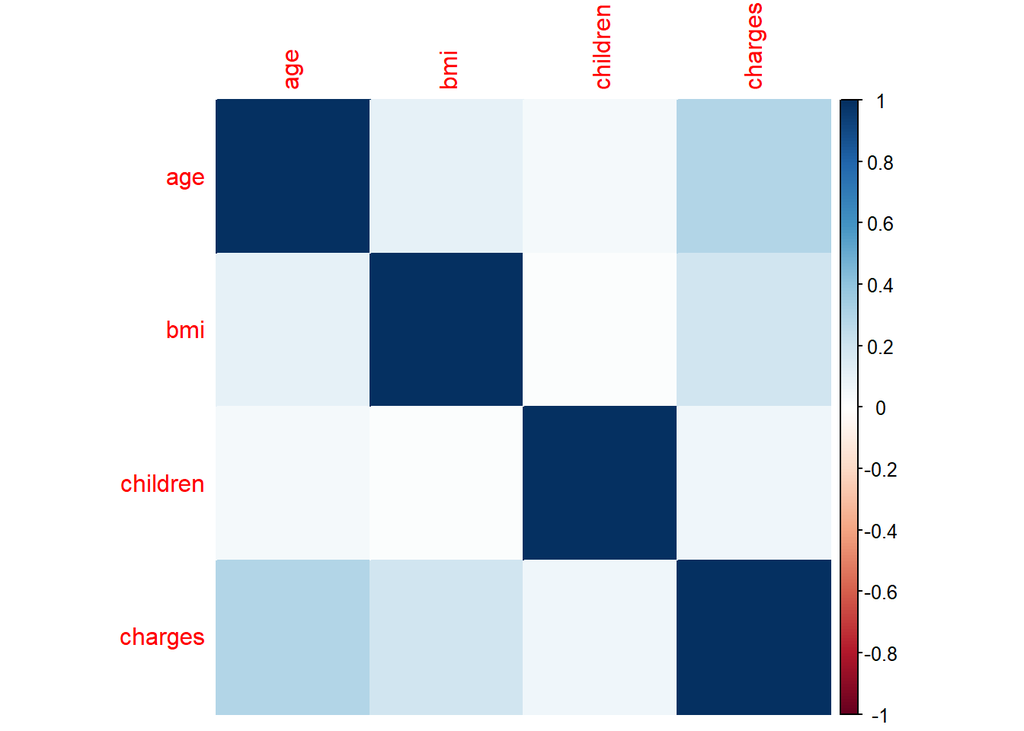

```r
insurance_corr <- insurance %>%
  select(-sex, -smoker, -region)

library(corrplot)
corrplot(cor(insurance_corr), method = "color")
```

The darker the color, the higher the correlation. Except for self-data, age and charges have the highest correlation, and secondly, bmi and charges have the high correlation.

```r
insurance %>%
  group_by(smoker) %>%
  summarise(avgage = mean(age))
```

```
## # A tibble: 2 x 2
##   smoker avgage
##   <chr>   <dbl>
## 1 no       39.4
## 2 yes      38.5
```

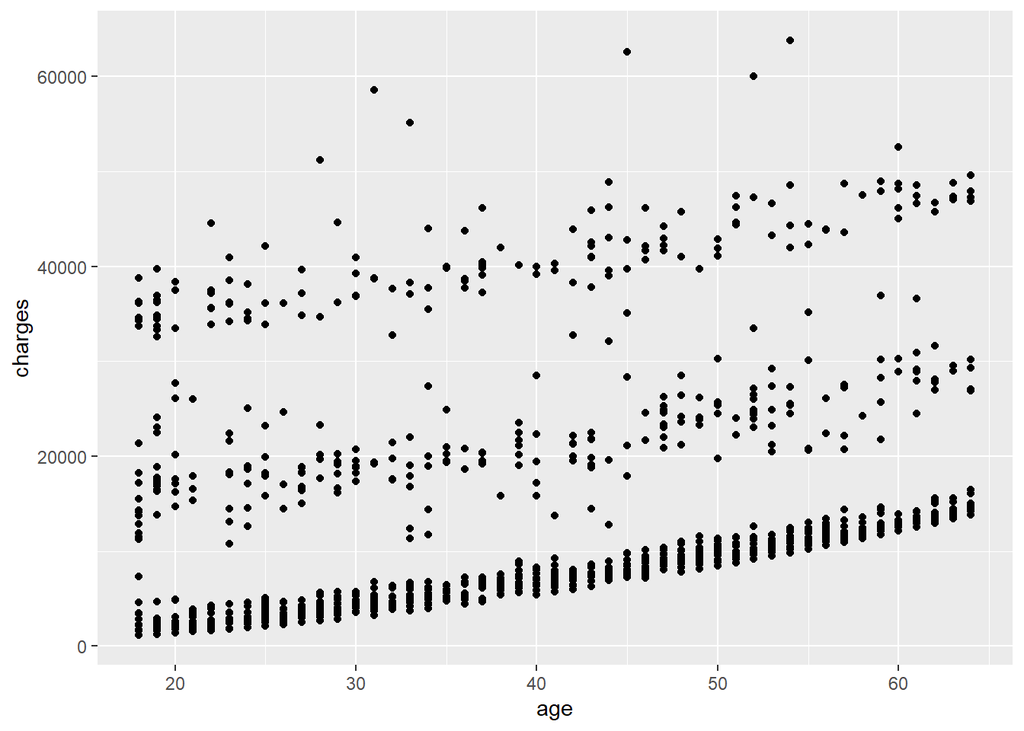

```r
ggplot(data = insurance) +
  geom_point(mapping = aes(x = age , y = charges))
```

```r
insurance %>% get_correlation(formula = charges ~ age)
```

```
## # A tibble: 1 x 1
##     cor
##   <dbl>
## 1 0.299
```

The positive sign indicates a positive correlation. In other words, as the age goes up, the price comes up and vice versa. The coefficient of 0.299 indicates a weakly positive correlation.

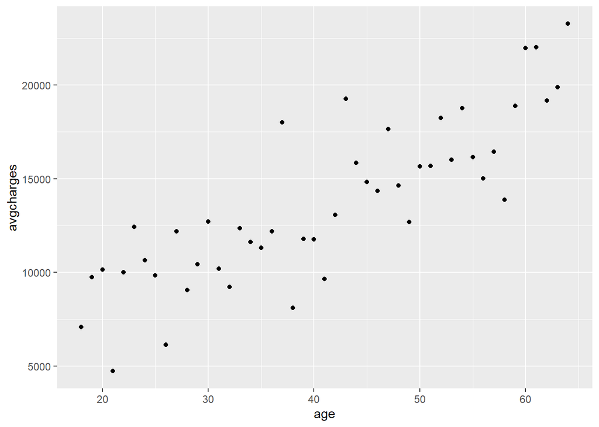

```r
insurance %>%
  group_by(age) %>%
  summarise(avgcharges = mean(charges)) %>%
  ggplot(aes(age, avgcharges)) +
  geom_point()
```

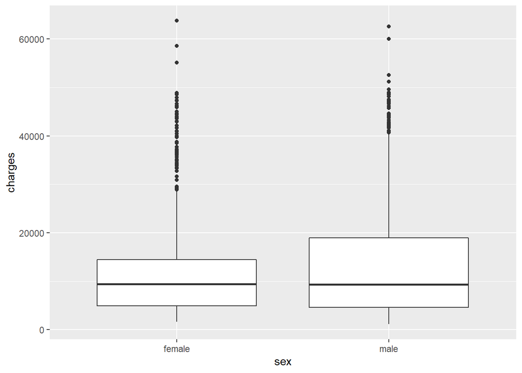

```r
ggplot(data = insurance, mapping = aes(x = sex , y = charges) ) +
  geom_boxplot()
```

```r
insurance %>%
  group_by(smoker) %>%
  summarise(avgbmi = mean(bmi))
```

```
## # A tibble: 2 x 2
##   smoker avgbmi
##   <chr>   <dbl>
## 1 no       30.7
## 2 yes      30.7
```

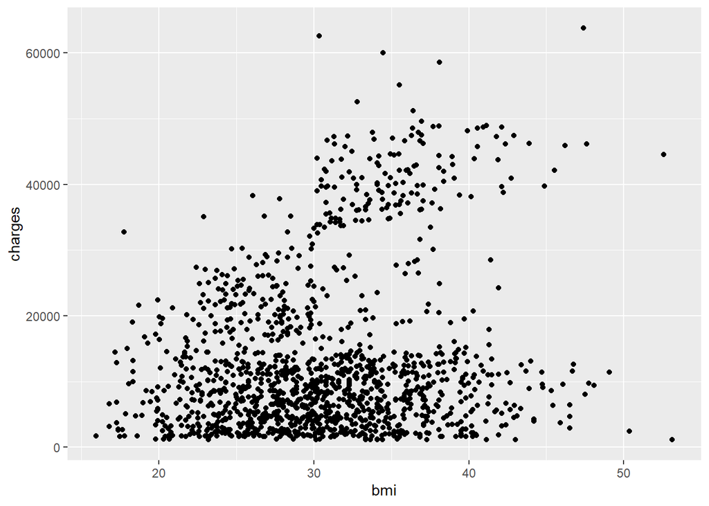

```r
ggplot(data = insurance) +
  geom_point(mapping = aes(x = bmi , y = charges ))
```

```r
insurance %>% get_correlation(formula = charges ~ bmi)
```

```
## # A tibble: 1 x 1
##     cor
##   <dbl>
## 1 0.198
```

The positive sign indicates a positive correlation. In other words, as the bmi goes up, the price comes up and vice versa. The coefficient of 0.198 indicates a weakly positive correlation.

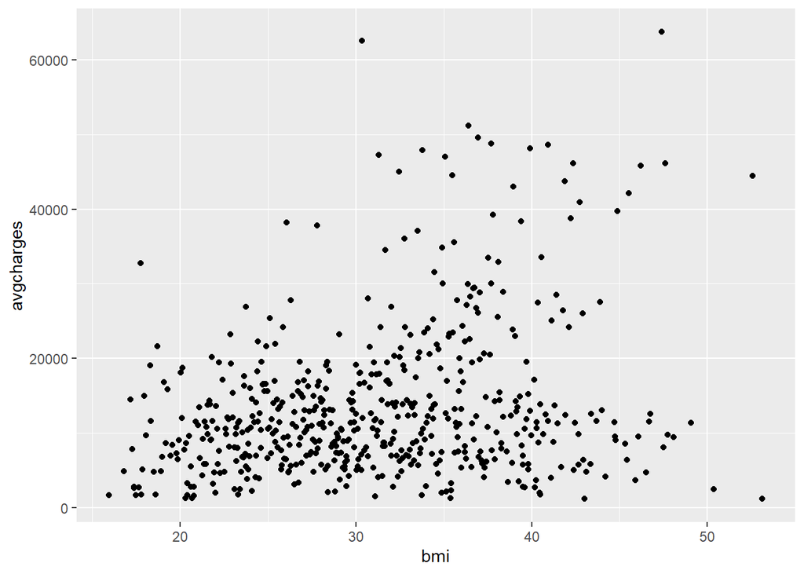

```r
insurance %>%
  group_by(bmi) %>%
  summarise(avgcharges = mean(charges)) %>%
  ggplot(aes(bmi, avgcharges)) +
  geom_point()
```

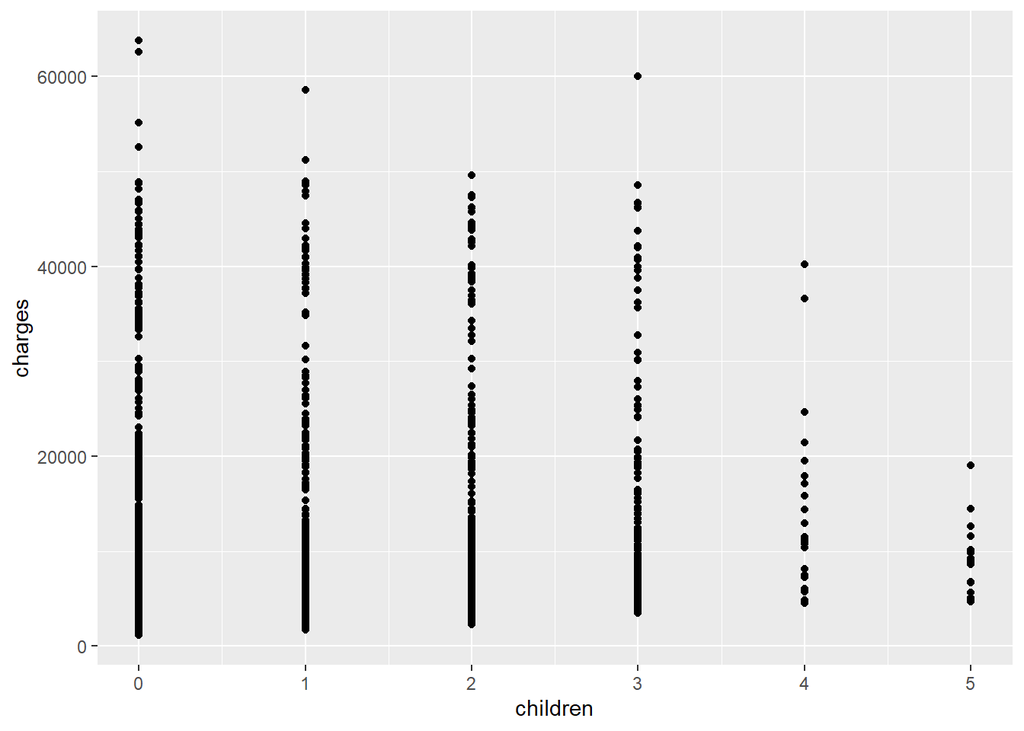

```r
ggplot(data = insurance) +
  geom_point(mapping = aes(x = children , y = charges))
```

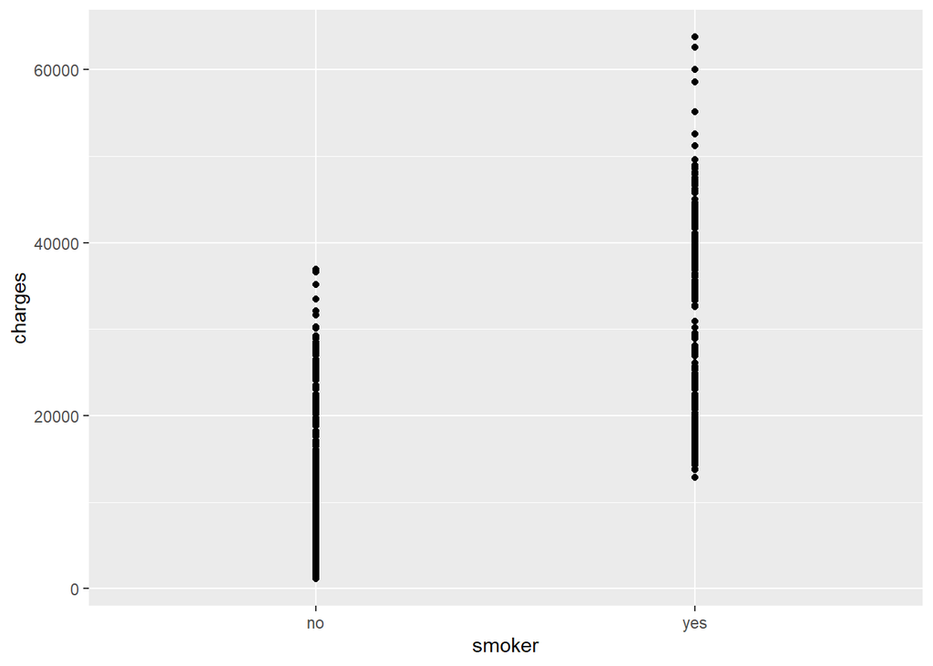

```r
ggplot(data = insurance) +
  geom_point(mapping = aes(x = smoker , y = charges ))
```

Looking at the relationship between the x and y variables, respectively, it is concluded that it would be appropriate to create a model with a linear relationship that predicts insurance premiums using age and bmi as x variables. Now I’ll try to look at each of the two variables in more detail.

```r
# Process missing values
insurance <- insurance %>%
  filter(!is.na(age) & !is.na(bmi) & !is.na(charges))
```

```r
# I want to see the distribution of data with insurance premiums of top 1%

insurance %>%
  filter(percent_rank(charges) > 0.99) %>%
  arrange(age, bmi)
```

```
## # A tibble: 14 x 7
##      age sex      bmi children smoker region    charges
##    <int> <chr>  <dbl>    <int> <chr>  <chr>       <dbl>
##  1    28 male    36.4        1 yes    southwest  51195.
##  2    31 female  38.1        1 yes    northeast  58571.
##  3    33 female  35.5        0 yes    northwest  55135.
##  4    44 female  38.1        0 yes    southeast  48885.
##  5    45 male    30.4        0 yes    southeast  62593.
##  6    52 male    34.5        3 yes    northwest  60021.
##  7    54 male    40.6        3 yes    northeast  48549.
##  8    54 female  47.4        0 yes    southeast  63770.
##  9    57 male    42.1        1 yes    southeast  48676.
## 10    59 male    41.1        1 yes    southeast  48970.
## 11    60 male    32.8        0 yes    southwest  52591.
## 12    60 male    40.9        0 yes    southeast  48674.
## 13    63 female  37.7        0 yes    southwest  48824.
## 14    64 male    37.0        2 yes    southeast  49578.
```

```r
insurance %>%
  filter(percent_rank(charges) > 0.99) %>%
  arrange(age, bmi) %>%
  mutate(nextcharges = lead(charges))
```

```
## # A tibble: 14 x 8
##      age sex      bmi children smoker region    charges nextcharges
##    <int> <chr>  <dbl>    <int> <chr>  <chr>       <dbl>       <dbl>
##  1    28 male    36.4        1 yes    southwest  51195.      58571.
##  2    31 female  38.1        1 yes    northeast  58571.      55135.
##  3    33 female  35.5        0 yes    northwest  55135.      48885.
##  4    44 female  38.1        0 yes    southeast  48885.      62593.
##  5    45 male    30.4        0 yes    southeast  62593.      60021.
##  6    52 male    34.5        3 yes    northwest  60021.      48549.
##  7    54 male    40.6        3 yes    northeast  48549.      63770.
##  8    54 female  47.4        0 yes    southeast  63770.      48676.
##  9    57 male    42.1        1 yes    southeast  48676.      48970.
## 10    59 male    41.1        1 yes    southeast  48970.      52591.
## 11    60 male    32.8        0 yes    southwest  52591.      48674.
## 12    60 male    40.9        0 yes    southeast  48674.      48824.
## 13    63 female  37.7        0 yes    southwest  48824.      49578.
## 14    64 male    37.0        2 yes    southeast  49578.         NA
```

```r
insurance %>%
  filter(percent_rank(charges) > 0.99) %>%
  arrange(age, bmi) %>%
  mutate(nextcharges = lag(charges))
```

```
## # A tibble: 14 x 8
##      age sex      bmi children smoker region    charges nextcharges
##    <int> <chr>  <dbl>    <int> <chr>  <chr>       <dbl>       <dbl>
##  1    28 male    36.4        1 yes    southwest  51195.         NA
##  2    31 female  38.1        1 yes    northeast  58571.      51195.
##  3    33 female  35.5        0 yes    northwest  55135.      58571.
##  4    44 female  38.1        0 yes    southeast  48885.      55135.
##  5    45 male    30.4        0 yes    southeast  62593.      48885.
##  6    52 male    34.5        3 yes    northwest  60021.      62593.
##  7    54 male    40.6        3 yes    northeast  48549.      60021.
##  8    54 female  47.4        0 yes    southeast  63770.      48549.
##  9    57 male    42.1        1 yes    southeast  48676.      63770.
## 10    59 male    41.1        1 yes    southeast  48970.      48676.
## 11    60 male    32.8        0 yes    southwest  52591.      48970.
## 12    60 male    40.9        0 yes    southeast  48674.      52591.
## 13    63 female  37.7        0 yes    southwest  48824.      48674.
## 14    64 male    37.0        2 yes    southeast  49578.      48824.
```

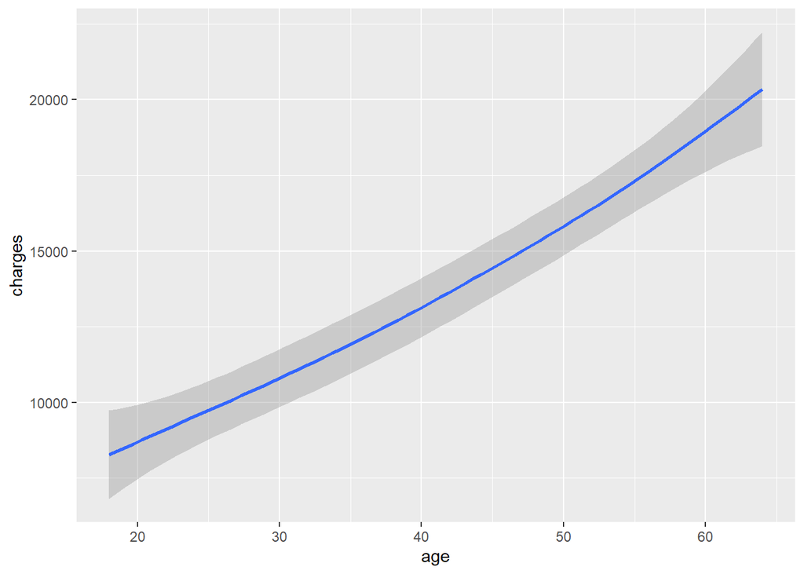

```r
# overall trend
ggplot(data = insurance) +
  geom_smooth(mapping = aes(x= age, y = charges))
```

```r
# When looking at the overall trend, it can be seen that there is a linear relationship.
```

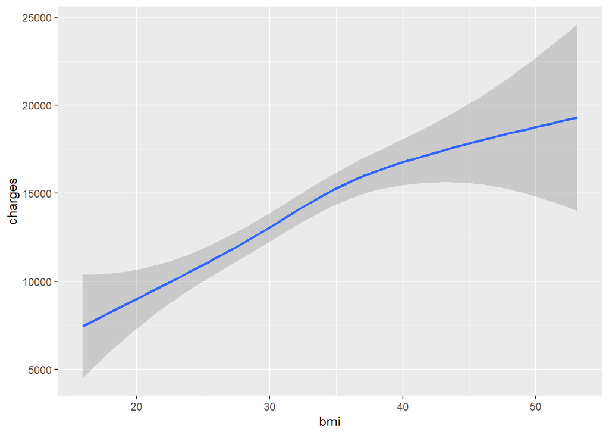

```r
# overall trend
ggplot(data = insurance) +
  geom_smooth(mapping = aes(x= bmi, y = charges))
```

```r
# Looking at the overall trend, it can be seen that although it is not a clear linear relationship than when x is age, it still shows a relatively linear relationship.
```

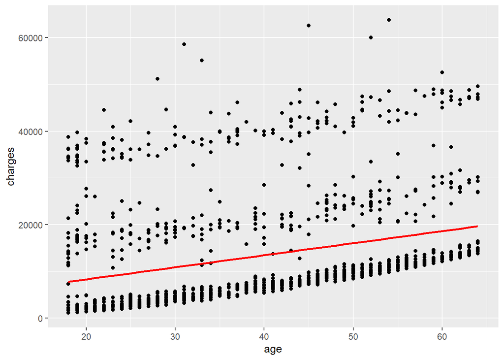

```r
# creating model
mod1 <- lm(charges ~ age, data = insurance)
grid1 <- insurance %>%
  data_grid(age)

grid1 <- grid1 %>%
  add_predictions(mod1)

ggplot(data = insurance) +
  geom_point(aes(x = age, y = charges))+
  geom_line(aes(x = age, y = pred), data = grid1, colour = "red", size = 1)
```

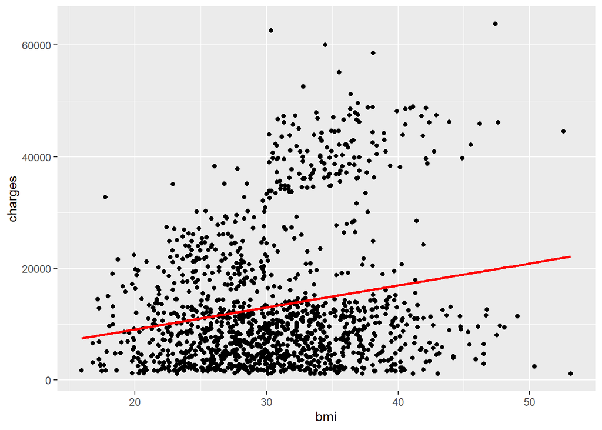

```r
# creating model
mod2 <- lm(charges ~ bmi, data = insurance)
grid2 <- insurance %>%
  data_grid(bmi)

grid2 <- grid2 %>%
  add_predictions(mod2)

ggplot(data = insurance) +
  geom_point(aes(x = bmi, y = charges))+
  geom_line(aes(x = bmi, y = pred), data = grid2, colour = "red", size = 1)
```

Each shows a roughly linear relationship, but in both variables, the slope is not large and the data is divided. In addition to these two x variables, it was thought that there were variables affecting the charges. Since the value of the smoker among the x variables is directly related to health, it is likely to have a direct effect on insurance premiums, so I will consider this variable and visualize it.

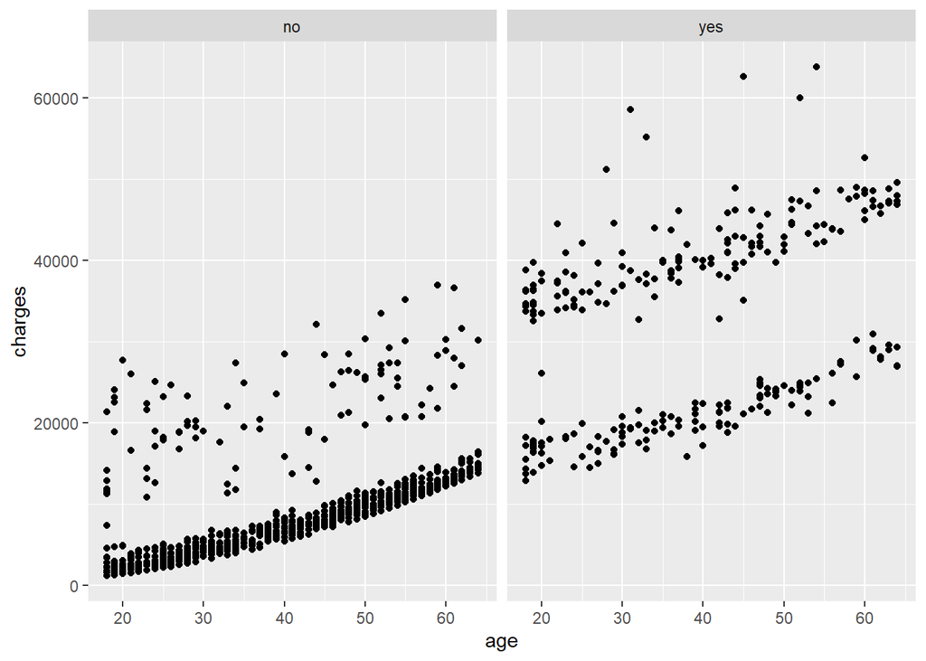

```r
ggplot(data = insurance) +
  geom_point(mapping = aes(x = age, y = charges))+
  facet_wrap(vars(smoker))
```

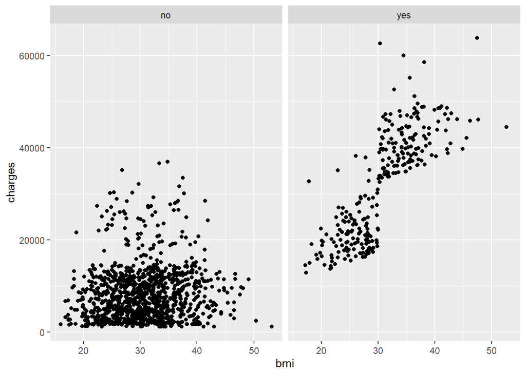

```r
ggplot(data = insurance) +
  geom_point(mapping = aes(x = bmi, y = charges))+
  facet_wrap(vars(smoker))
```

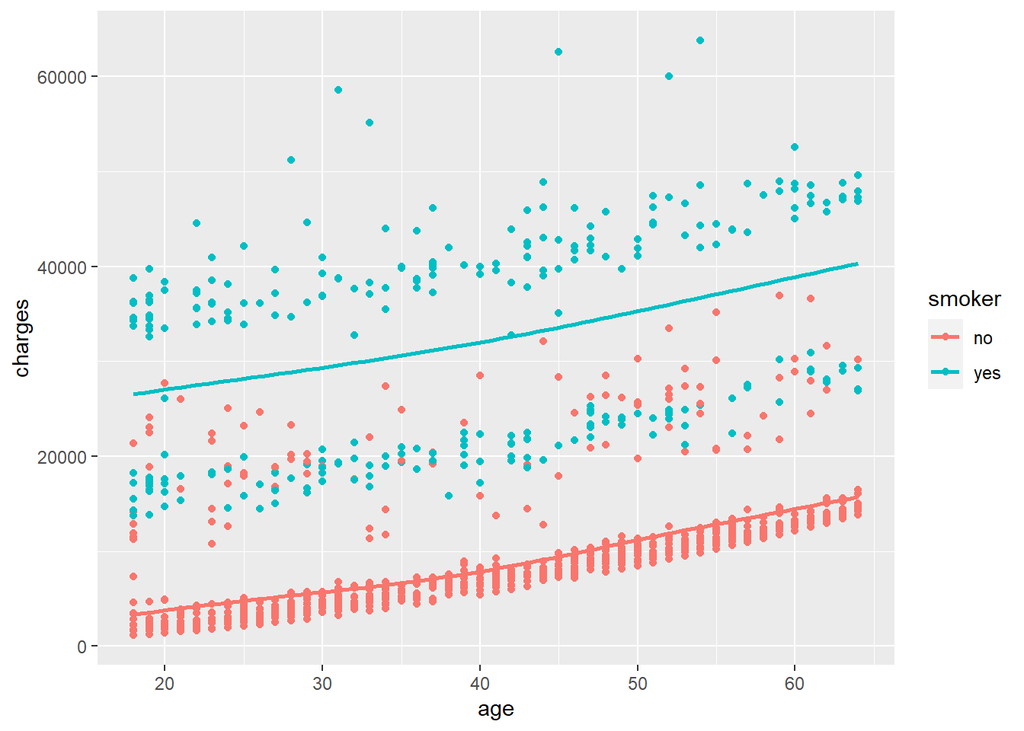

```r
ggplot(data = insurance, aes(x=age, y=charges, colour = smoker)) +
  geom_point()+
  geom_smooth(se = FALSE)
```

```r
# In this way, it can be confirmed that people who are smoker have to pay much higher premiums than people who are not smoker.
```

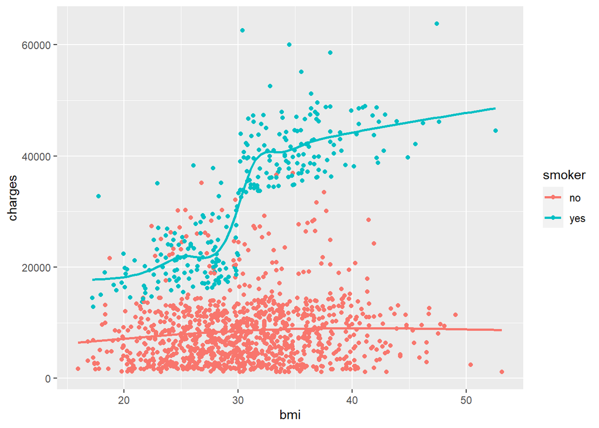

```r
ggplot(data = insurance, aes(x=bmi, y=charges, colour = smoker)) +
  geom_point()+
  geom_smooth(se = FALSE)
```

```r
# Similarly, even when x is bmi, whether or not it is smoker has a great influence on charges.
```

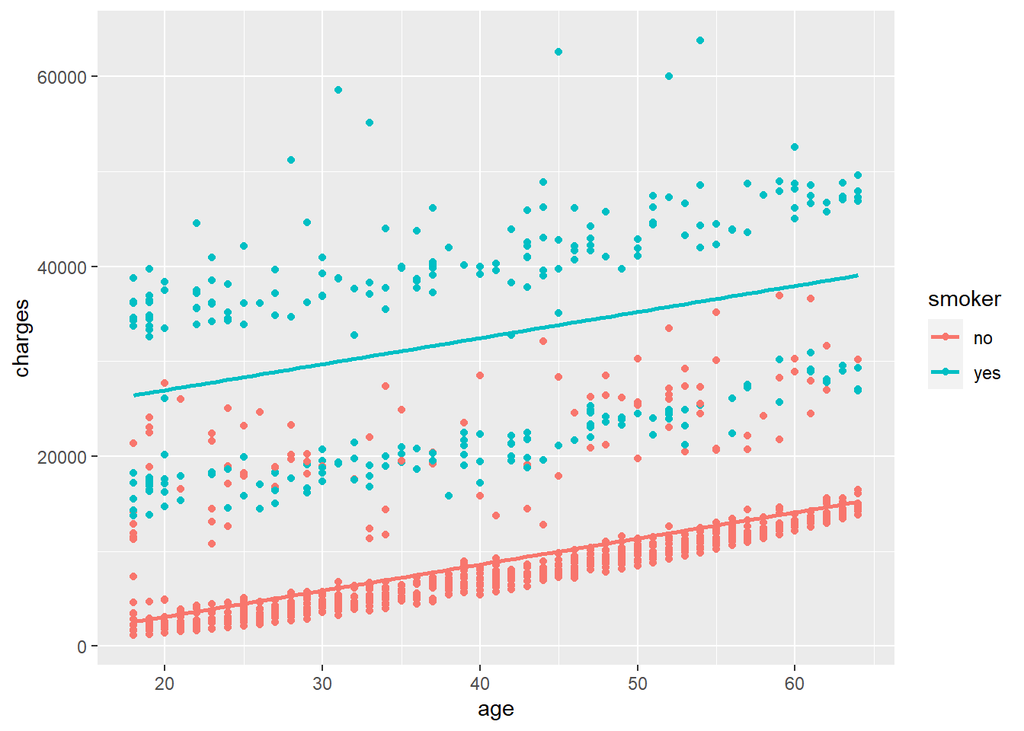

```r
#multiple linear regression
insurance %>% ggplot(aes(x = age, y = charges, color = smoker)) +
  geom_point() +
  geom_parallel_slopes(se = FALSE)
```

```r
age_model_parallel_slopes <- lm(charges ~ age, data = insurance)
age_model_parallel_slopes %>% get_regression_table()
```

```
## # A tibble: 2 x 7
##   term      estimate std_error statistic p_value lower_ci upper_ci
##   <chr>        <dbl>     <dbl>     <dbl>   <dbl>    <dbl>    <dbl>
## 1 intercept    3166.     937.       3.38   0.001    1327.    5004.
## 2 age           258.      22.5     11.5    0         214.     302.
```

b0 = 3165.885, b1 = 257.723 $\widehat{charges} = 3165.885 + 257.723 . age$ The slope b1 = 257.723 suggests a positive relationship between the age and insurance premiums(charges), meaning as the age increases, the charges increases.

The intercept is the expected mean value of charges.

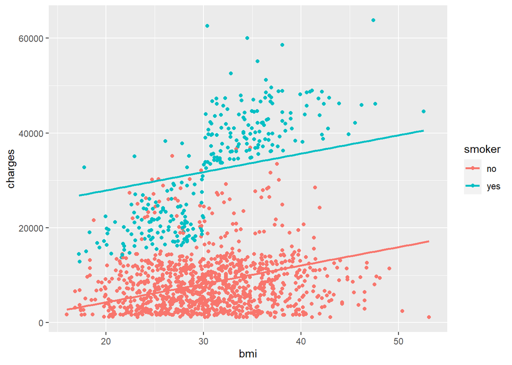

```r
#multiple linear regression
insurance %>% ggplot(aes(x = bmi, y = charges, color = smoker)) +
  geom_point() +
  geom_parallel_slopes(se = FALSE)
```

```r
bmi_model_parallel_slopes <- lm(charges ~ bmi, data = insurance)
bmi_model_parallel_slopes %>% get_regression_table()
```

```
## # A tibble: 2 x 7
##   term      estimate std_error statistic p_value lower_ci upper_ci
##   <chr>        <dbl>     <dbl>     <dbl>   <dbl>    <dbl>    <dbl>
## 1 intercept    1193.    1665.      0.717   0.474   -2073.    4459.
## 2 bmi           394.      53.3     7.40    0         289.     498.
```

The intercept is the expected mean value of charges.

```r
#interaction model

model_interaction <- lm(charges ~ age * bmi, data = insurance)
model_interaction %>% get_regression_table()
```

```
## # A tibble: 4 x 7
##   term      estimate std_error statistic p_value  lower_ci upper_ci
##   <chr>        <dbl>     <dbl>     <dbl>   <dbl>     <dbl>    <dbl>
## 1 intercept -9163.     4634.      -1.98    0.048 -18253.     -72.0
## 2 age         314.      115.       2.74    0.006     88.7    539.
## 3 bmi         422.      149.       2.83    0.005    130.     715.
## 4 age:bmi      -2.32      3.64    -0.638   0.524     -9.46     4.82
```

$\widehat{charges} = -9162.555 + 313.657 . age + 422.247 . bmi - 2.321.age.bmi$

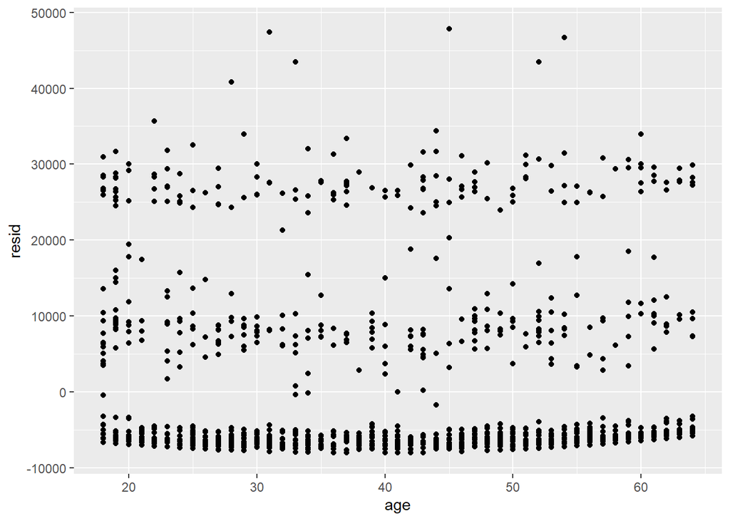

```r
# After removing the strong smoker effect, I will look at each relationship again.

insurance <- insurance %>%
  add_residuals(mod1)

insurance %>%
  ggplot(aes(age, resid)) +
  geom_point()
```

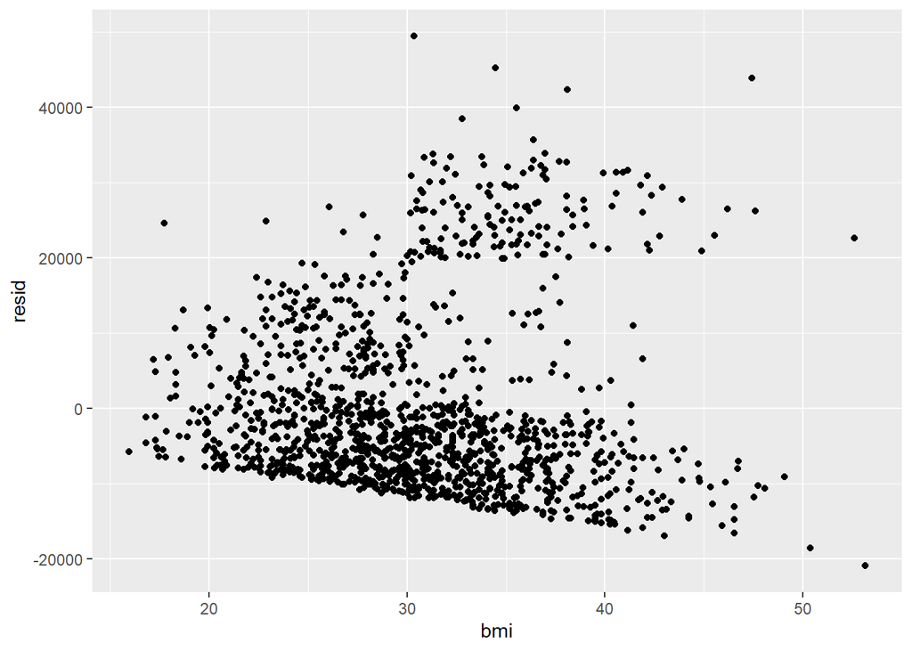

```r
# After removing the strong smoker effect, I will look at each relationship again.

insurance <- insurance %>%
  add_residuals(mod2)

insurance %>%
  ggplot(aes(bmi, resid)) +
  geom_point()
```

```r
# I will set up a prediction model for each according to whether it is a smoker or not.

y_smoker <- insurance %>%
  filter(smoker == 'yes') # if smoker

n_smoker <- insurance %>%
  filter(smoker == 'no') # if non-smoker
```

```r
y_smoker %>% get_correlation(formula = charges ~ age)
```

```
## # A tibble: 1 x 1
##     cor
##   <dbl>
## 1 0.368
```

```r
n_smoker %>% get_correlation(formula = charges ~ age)
```

```
## # A tibble: 1 x 1
##     cor
##   <dbl>
## 1 0.628
```

```r
y_smoker %>% get_correlation(formula = charges ~ bmi)
```

```
## # A tibble: 1 x 1
##     cor
##   <dbl>
## 1 0.806
```

```r
n_smoker %>% get_correlation(formula = charges ~ bmi)
```

```
## # A tibble: 1 x 1
##      cor
##    <dbl>
## 1 0.0840
```

The positive sign indicates a positive correlation. It shows the highest correlation(0.806) when it is a smoker and when x is bmi.

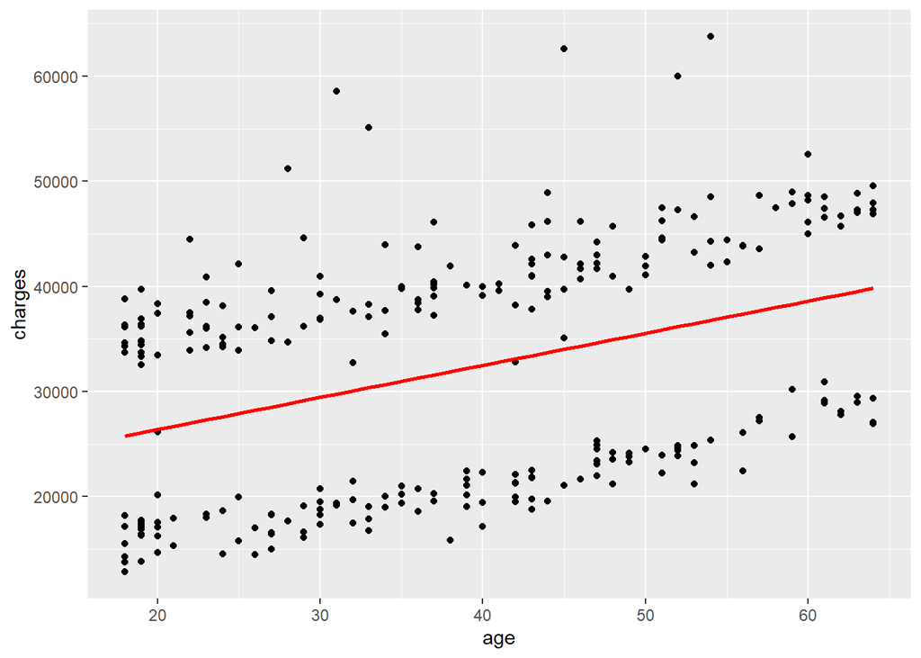

```r
# if smoker, when x is age
mod3 <- lm(charges ~ age, data = y_smoker)
grid3 <- y_smoker %>%
  data_grid(age)

grid3 <- grid3 %>%
  add_predictions(mod3)

ggplot(data = y_smoker) +
  geom_point(aes(x = age, y = charges))+
  geom_line(aes(x = age, y = pred), data = grid3, colour = "red", size = 1)
```

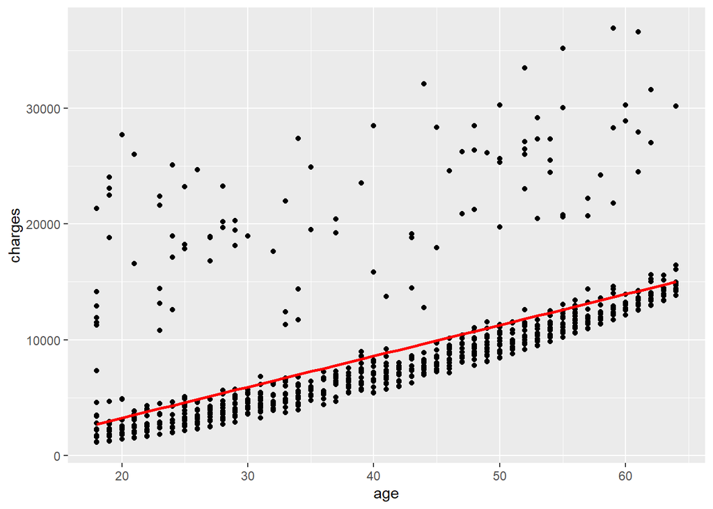

```r
# if non-smoker, when x is age
mod4 <- lm(charges ~ age, data = n_smoker)
grid4 <- n_smoker %>%
  data_grid(age)

grid4 <- grid4 %>%
  add_predictions(mod4)

ggplot(data = n_smoker) +
  geom_point(aes(x = age, y = charges))+
  geom_line(aes(x = age, y = pred), data = grid4, colour = "red", size = 1)
```

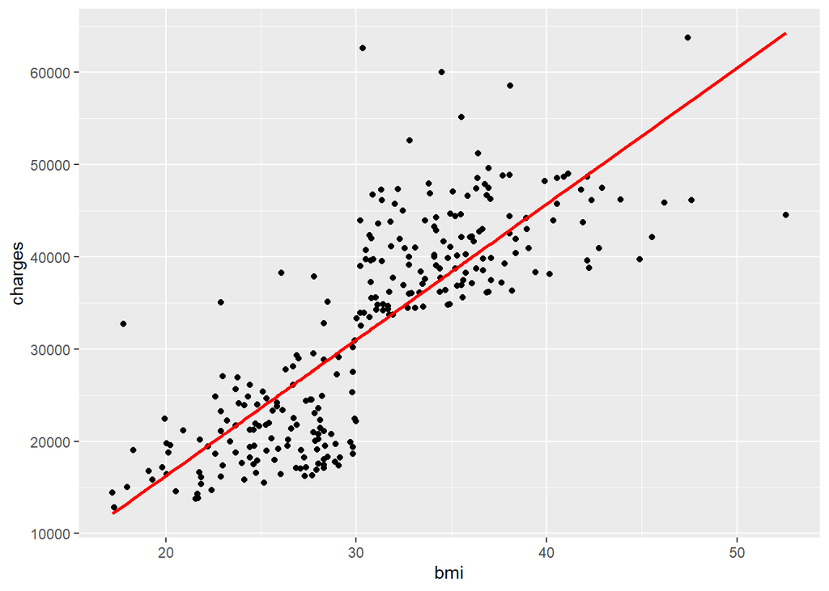

```r
# if smoker, when x is bmi
mod5 <- lm(charges ~ bmi, data = y_smoker)
grid5 <- y_smoker %>%
  data_grid(bmi)

grid5 <- grid5 %>%
  add_predictions(mod5)

ggplot(data = y_smoker) +
  geom_point(aes(x = bmi, y = charges))+
  geom_line(aes(x = bmi, y = pred), data = grid5, colour = "red", size = 1)
```

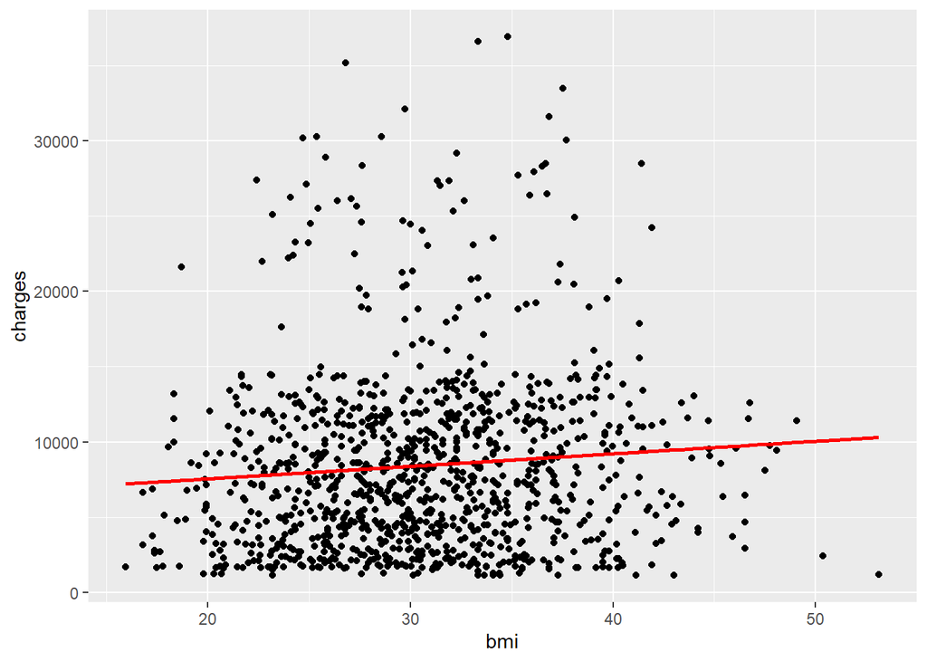

```r
# if non-smoker, when x is bmi
mod6 <- lm(charges ~ bmi, data = n_smoker)
grid6 <- n_smoker %>%
  data_grid(bmi)

grid6 <- grid6 %>%
  add_predictions(mod6)

ggplot(data = n_smoker) +
  geom_point(aes(x = bmi, y = charges))+
  geom_line(aes(x = bmi, y = pred), data = grid6, colour = "red", size = 1)
```

Comparing the slope, it can be seen that when the smoker and the x variable are bmi, the value of the premium increases steeply.

Null hypothesis, H0 : The insurance premiums are not affected by the bmi and smoking.

Alternative hypothesis, HA : The insurance premiums depend on the bmi and smoking.

The null hypothesis H0 assumes that the slope is 0 and that there is no true relationship between bmi, smoking and charges.

The alternative hypothesis HA assumes that the slope is not 0, which means that as the bmi increases and it is smoker, its charges either increases (positive slope) or decreases (negative slope).

```r
# if smoker, when x is bmi
mod5 %>% get_regression_table()
```

```
## # A tibble: 2 x 7
##   term      estimate std_error statistic p_value lower_ci upper_ci
##   <chr>        <dbl>     <dbl>     <dbl>   <dbl>    <dbl>    <dbl>
## 1 intercept  -13187.    2053.      -6.42       0  -17228.   -9145.
## 2 bmi          1473.      65.5     22.5        0    1344.    1602.
```

The p-value of 0 for both the intercept b0 of -13186.576 and the observed fitted slope b1 of 1473.106 suggests that we could reject the hypothesis that there is no relationship between bmi and charges (the null hypothesis) in favour of the hypothesis that there is (the alternative hypothesis).

The two rightmost columns of the regression table (lower_ci and upper_ci) correspond to the endpoints of the 95% confidence interval. We are 95% confident that the true intercept (price of new house) lies in the range (-17228.140, -9145.013) and that the true slope lies in the range (1344.187, 1602.026).

Note that this CI of the slope does not contain 0; this is another indicator that our null hypothesis does not hold; there is indeed a meaningful relationship between bmi and charges when it is smoker.

I will also check using summary().

```r
# if smoker, when x is age
summary(mod3)
```

```
##
## Call:
## lm(formula = charges ~ age, data = y_smoker)
##
## Residuals:
##    Min     1Q Median     3Q    Max
## -16072 -11137   5764   8592  28815
##
## Coefficients:
##             Estimate Std. Error t value Pr(>|t|)
## (Intercept) 20294.13    1913.40  10.606  < 2e-16 ***
## age           305.24      46.73   6.532 3.18e-10 ***
## ---
## Signif. codes:  0 '***' 0.001 '**' 0.01 '*' 0.05 '.' 0.1 ' ' 1
##
## Residual standard error: 10750 on 272 degrees of freedom
## Multiple R-squared:  0.1356, Adjusted R-squared:  0.1324
## F-statistic: 42.67 on 1 and 272 DF,  p-value: 3.181e-10
```

```r
# if non-smoker, when x is age
summary(mod4)
```

```
##
## Call:
## lm(formula = charges ~ age, data = n_smoker)
##
## Residuals:
##     Min      1Q  Median      3Q     Max
## -3182.9 -1948.6 -1363.8  -665.2 24470.7
##
## Coefficients:
##             Estimate Std. Error t value Pr(>|t|)
## (Intercept) -2091.42     425.10   -4.92    1e-06 ***
## age           267.25      10.16   26.29   <2e-16 ***
## ---
## Signif. codes:  0 '***' 0.001 '**' 0.01 '*' 0.05 '.' 0.1 ' ' 1
##
## Residual standard error: 4667 on 1062 degrees of freedom
## Multiple R-squared:  0.3943, Adjusted R-squared:  0.3937
## F-statistic: 691.4 on 1 and 1062 DF,  p-value: < 2.2e-16
```

```r
# if smoker, when x is bmi
summary(mod5)
```

```
##
## Call:
## lm(formula = charges ~ bmi, data = y_smoker)
##
## Residuals:
##      Min       1Q   Median       3Q      Max
## -19768.0  -4487.9     34.4   3263.9  31055.9
##
## Coefficients:
##              Estimate Std. Error t value Pr(>|t|)
## (Intercept) -13186.58    2052.88  -6.423 5.93e-10 ***
## bmi           1473.11      65.48  22.496  < 2e-16 ***
## ---
## Signif. codes:  0 '***' 0.001 '**' 0.01 '*' 0.05 '.' 0.1 ' ' 1
##
## Residual standard error: 6837 on 272 degrees of freedom
## Multiple R-squared:  0.6504, Adjusted R-squared:  0.6491
## F-statistic: 506.1 on 1 and 272 DF,  p-value: < 2.2e-16
```

```r
# if non-smoker, when x is bmi
summary(mod6)
```

```
##
## Call:
## lm(formula = charges ~ bmi, data = n_smoker)
##
## Residuals:
##    Min     1Q Median     3Q    Max
##  -9144  -4360  -1009   2922  28131
##
## Coefficients:
##             Estimate Std. Error t value Pr(>|t|)
## (Intercept)  5879.42     947.48   6.205 7.81e-10 ***
## bmi            83.35      30.33   2.748  0.00609 **
## ---
## Signif. codes:  0 '***' 0.001 '**' 0.01 '*' 0.05 '.' 0.1 ' ' 1
##
## Residual standard error: 5975 on 1062 degrees of freedom
## Multiple R-squared:  0.007062,   Adjusted R-squared:  0.006127
## F-statistic: 7.553 on 1 and 1062 DF,  p-value: 0.006091
```

Looking at how well each variable explains the insurance premium, which is the y value, through Multiple R-sqaured, it can be seen that when it is smoker, and x is bmi, it shows the highest value at 0.6504.

Next, assuming that age and bmi interact with each other, we will check what model will come out if we predict the premiums.

```r
# if smoker
mod7 <- lm(charges ~ age*bmi, data = y_smoker)
summary(mod7)
```

```
##
## Call:
## lm(formula = charges ~ age * bmi, data = y_smoker)
##
## Residuals:
##      Min       1Q   Median       3Q      Max
## -12153.0  -4250.8   -278.7   3614.7  29393.3
##
## Coefficients:
##               Estimate Std. Error t value Pr(>|t|)
## (Intercept) -13899.770   5175.823  -2.686  0.00769 **
## age             38.951    131.392   0.296  0.76711
## bmi           1164.775    164.551   7.078 1.26e-11 ***
## age:bmi          7.308      4.147   1.762  0.07914 .
## ---
## Signif. codes:  0 '***' 0.001 '**' 0.01 '*' 0.05 '.' 0.1 ' ' 1
##
## Residual standard error: 5732 on 270 degrees of freedom
## Multiple R-squared:  0.756,  Adjusted R-squared:  0.7533
## F-statistic: 278.9 on 3 and 270 DF,  p-value: < 2.2e-16
```

```r
# if non-smoker
mod8 <- lm(charges ~ age*bmi, data = n_smoker)
summary(mod8)
```

```
##
## Call:
## lm(formula = charges ~ age * bmi, data = n_smoker)
##
## Residuals:
##     Min      1Q  Median      3Q     Max
## -3239.7 -1943.2 -1361.8  -662.4 24495.0
##
## Coefficients:
##               Estimate Std. Error t value Pr(>|t|)
## (Intercept) -1483.3671  2132.7763  -0.696    0.487
## age           245.8000    52.3931   4.691 3.07e-06 ***
## bmi           -19.4289    68.8865  -0.282    0.778
## age:bmi         0.6835     1.6662   0.410    0.682
## ---
## Signif. codes:  0 '***' 0.001 '**' 0.01 '*' 0.05 '.' 0.1 ' ' 1
##
## Residual standard error: 4671 on 1060 degrees of freedom
## Multiple R-squared:  0.3945, Adjusted R-squared:  0.3927
## F-statistic: 230.2 on 3 and 1060 DF,  p-value: < 2.2e-16
```

In conclusion, it can be said that multiple R-squared has the highest explanatory power for y (insurance premium) among the models made so far, assuming that it is smoker, and the age & BMI are interactive.